# GLMs for Car Insurance Pricing: Initial Data Exploration

## 2.4 Univariate Plots Facetted by Claim

Now we split the data into two groups: those policies with no claims and those with at least one claim. We then create some univariate plots of the input data and facet one the claim/noclaim variable to get an idea of any differences between the two groups.

```r
claim_noclaim_dt <- policyclaim_dt %>%
    mutate(claim = claim_count > 0)
```

Now that we have this data, we do the same thing as before, create the univariate plots of the categorical and numeric variables, and we facet on whether or not the policies have had a claim. This allows us to make direct comparisons across the variables.

As before, we start with the numeric variables first:

```
## claim_count
```

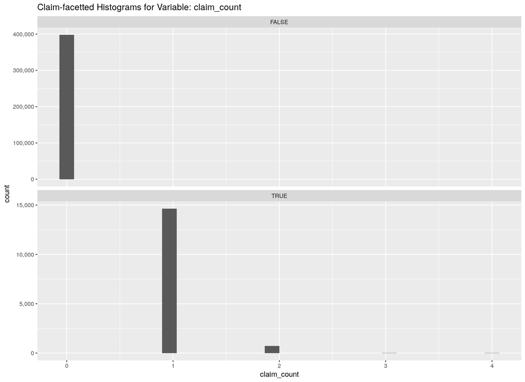

```
## exposure
```

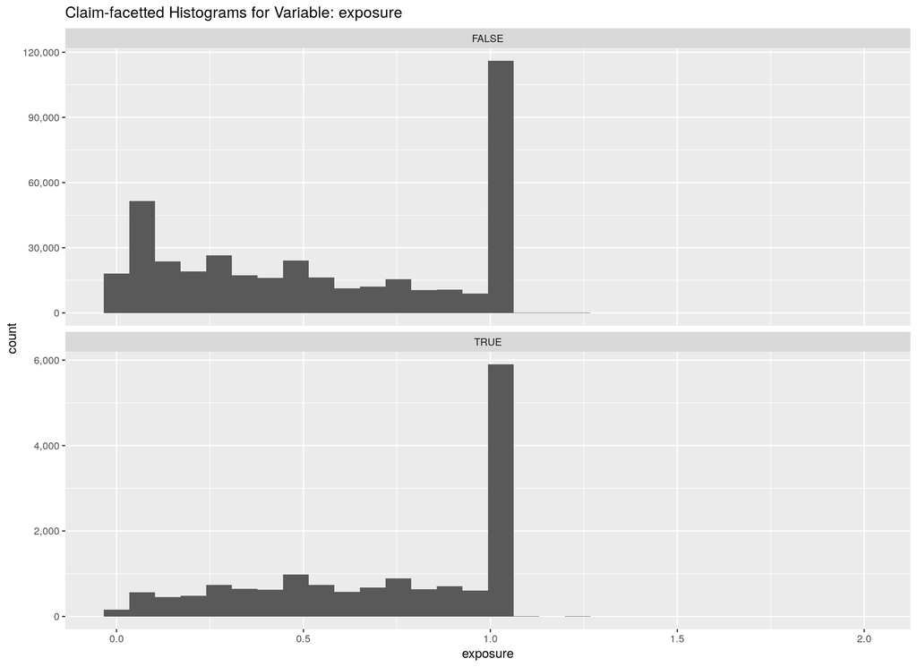

```
## car_age
```

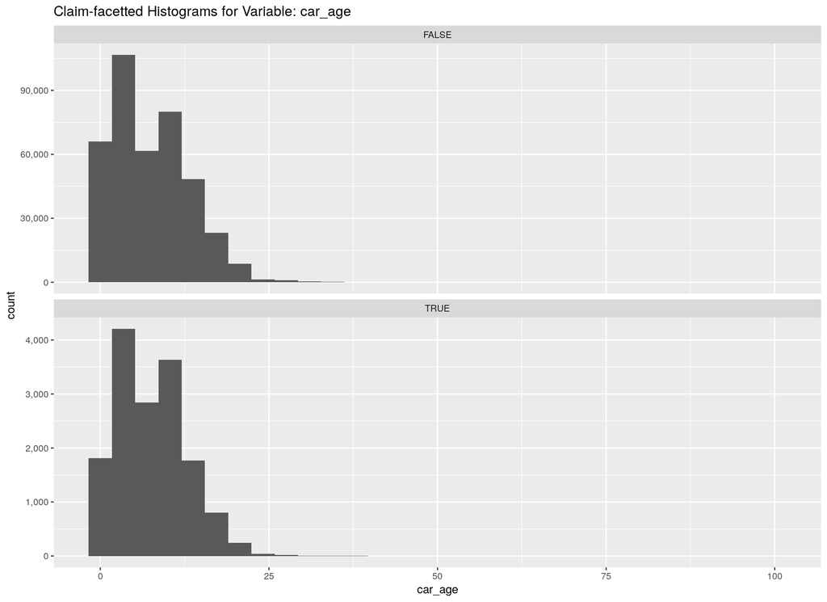

```
## driver_age
```

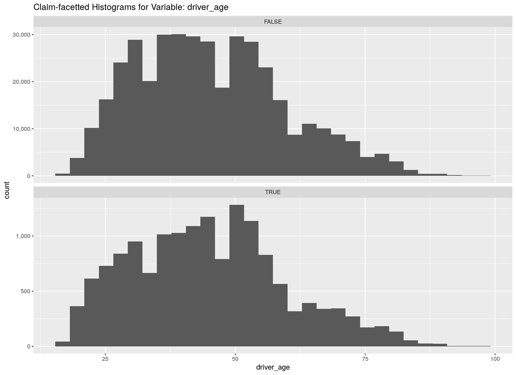

```
## density
```

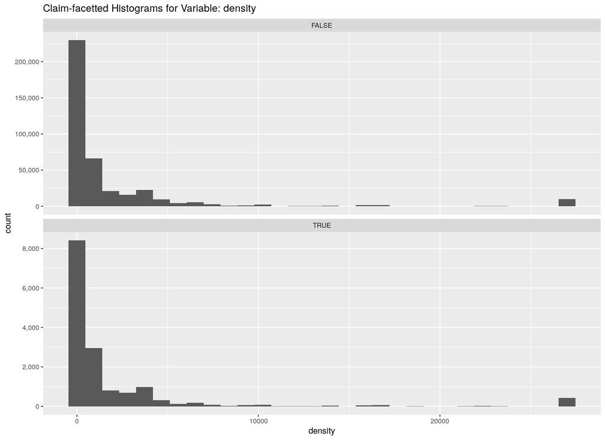

```r
for(plot_var in vars_num) {
    cat(paste0(plot_var, "\n"))

    plotdata_dt <- claim_noclaim_dt %>%
        select_(plot_var, "claim") %>%
        mutate_(use_var = plot_var)

    explore_plot <- ggplot(plotdata_dt) +
        geom_histogram(aes(x = use_var), bins = 30) +
        facet_wrap(~claim, scales = 'free_y', nrow = 2) +
        scale_y_continuous(labels = scales::comma) +
        xlab(plot_var) +
        ggtitle(paste0("Claim-facetted Histograms for Variable: ", plot_var))

    plot(explore_plot)
}
```

Apart from the obvious distinction between claim counts, there appears to be very little difference across the two groups, so we take a look at categorical variables.

```
## power
```

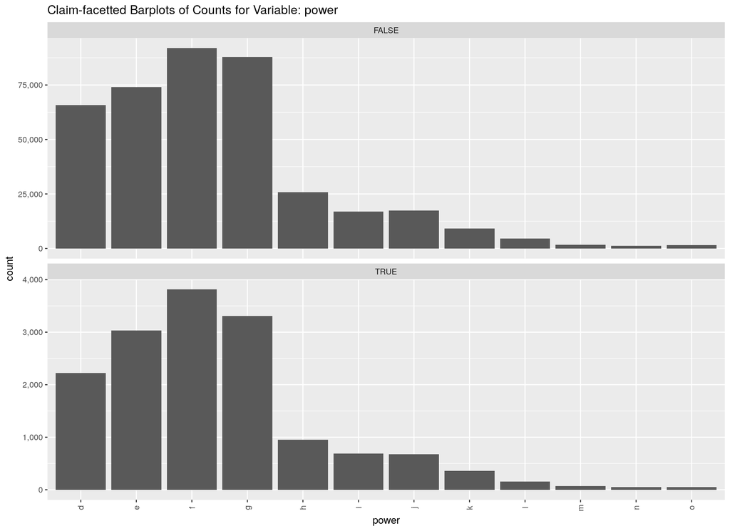

```
## brand
```

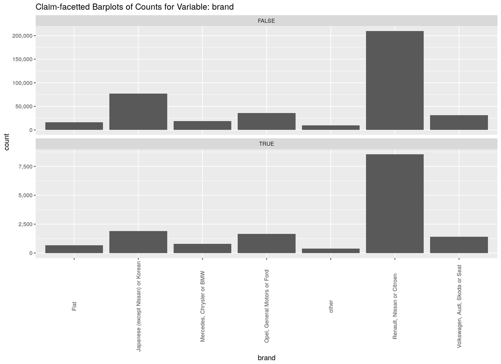

```
## fuel
```

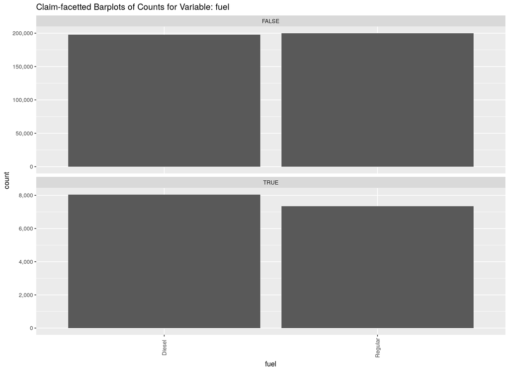

```
## region
```

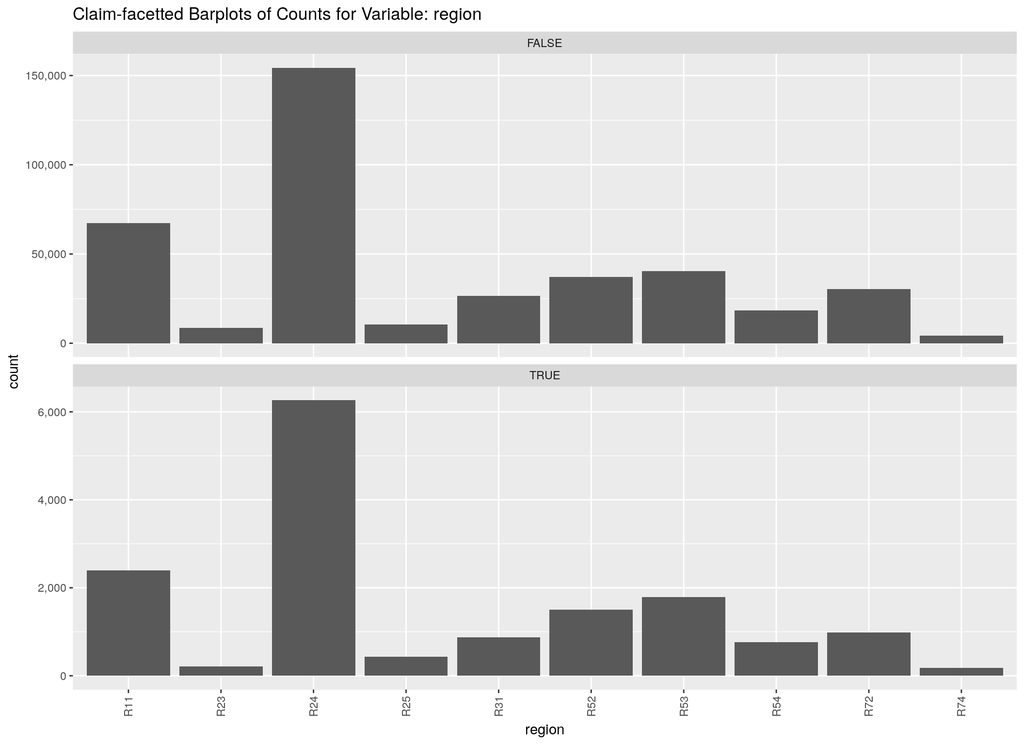

```r
for(plot_var in vars_cat) {
    cat(paste0(plot_var, "\n"))

    plotdata_dt <- claim_noclaim_dt %>%
        select_(plot_var, "claim") %>%
        mutate_(use_var = plot_var)

    explore_plot <- ggplot(plotdata_dt) +
        geom_bar(aes(x = use_var)) +
        facet_wrap(~claim, scales = 'free_y', nrow = 2) +
        scale_y_continuous(labels = scales::comma) +
        xlab(plot_var) +
        ggtitle(paste0("Claim-facetted Barplots of Counts for Variable: ", plot_var)) +
        theme(axis.text.x = element_text(angle = 90, vjust = 0.5))

    plot(explore_plot)
}
```

# 3 Data Cleaning

We now turn our attention to data cleaning and feature creation in the data. We do not have any premium information for the policy data, and may wish to convert some of the features from continuous to categorical - especially for variables such as age where we expect a non-linear influence on the output.

We may exclude data from the analysis if they are outliers.

One issue with removing outliers at this stage is that we are not entirely sure what counts as an outlier. It may be safer for the moment to leave them in and perhaps filter them out just prior to modelling when we have a better sense of what to do. We may wish to keep all the data for moment and split the modelling tasks into different parts, capturing different aspects of the data in different ways.

For the moment, we will leave the data intact.

# 4 Feature Creation

We turn our attention to adding new variables to our dataset to assist with the modelling. Before we do this, we should look at a summary of the data.

```r
summary(policyclaim_dt)
```

```
##    policy_id       claim_count        exposure           power          car_age
##  Min.   :     1   Min.   :0.0000   Min.   :0.00273   f      :95718   Min.   :  0.00
##  1st Qu.:103293   1st Qu.:0.0000   1st Qu.:0.20000   g      :91198   1st Qu.:  3.00
##  Median :206585   Median :0.0000   Median :0.54000   e      :77022   Median :  7.00
##  Mean   :206585   Mean   :0.0392   Mean   :0.56109   d      :68014   Mean   :  7.53
##  3rd Qu.:309877   3rd Qu.:0.0000   3rd Qu.:1.00000   h      :26698   3rd Qu.: 12.00
##  Max.   :413169   Max.   :4.0000   Max.   :1.99000   j      :18038   Max.   :100.00
##                                                      (Other):36481
##    driver_age                                  brand             fuel
##  Min.   :18.0   Fiat                              : 16723   Diesel :205945
##  1st Qu.:34.0   Japanese (except Nissan) or Korean: 79060   Regular:207224
##  Median :44.0   Mercedes, Chrysler or BMW         : 19280
##  Mean   :45.3   Opel, General Motors or Ford      : 37402
##  3rd Qu.:54.0   other                             :  9866
##  Max.   :99.0   Renault, Nissan or Citroen        :218200
##                 Volkswagen, Audi, Skoda or Seat   : 32638
##      region          density        num_claim       total_claims
##  R24    :160601   Min.   :    2   Min.   :1        Min.   :      0
##  R11    : 69791   1st Qu.:   67   1st Qu.:1        1st Qu.:      0
##  R53    : 42122   Median :  287   Median :1        Median :      0
##  R52    : 38751   Mean   : 1985   Mean   :1        Mean   :     83
##  R72    : 31329   3rd Qu.: 1410   3rd Qu.:1        3rd Qu.:      0
##  R31    : 27285   Max.   :27000   Max.   :4        Max.   :2036833
##  (Other): 43290                   NA's   :397779
```

From our initial data exploration in the previous document, we have a few manipulations that may be worthwhile. We will bin some of the numeric variables, and we might combine a number of levels in some categorical variables to reduce the amount of work required.

## 4.1 Binning Continuous Variables

We aggregate a few of the continuous features that are unlikely to have any kind of linear response in terms of the data: `driver_age`, `car_age` and `density`.

We have picked a somewhat arbitrary set of cutoffs to discretise the variables for these three variables and will check their use in the models we build.

```r
policyclaim_dt <- policyclaim_dt %>%
    mutate(cat_driver_age = cut(driver_age, c(17,22,26,42,74,Inf))
          ,cat_car_age    = cut(car_age,    c(0,1,4,15,Inf)
                               ,include.lowest = TRUE)
          ,cat_density    = cut(density, c(0,40,200,500,4500,Inf)
                               ,include.lowest = TRUE)) %>%
    mutate(cat_driver_age = as.character(cat_driver_age)
          ,cat_car_age    = as.character(cat_car_age)
          ,cat_density    = as.character(cat_density))

glimpse(policyclaim_dt)
```

```
## Observations: 413,169
## Variables: 15
## $ policy_id      <int> 1, 2, 3, 4, 5, 6, 7, 8, 9, 10, 11, 12, 13, 14, 15, 16, 17, 18,...
## $ claim_count    <int> 0, 0, 0, 0, 0, 0, 0, 0, 0, 0, 0, 0, 0, 0, 0, 0, 0, 0, 0, 0, 0,...
## $ exposure       <dbl> 0.09, 0.84, 0.52, 0.45, 0.15, 0.75, 0.81, 0.05, 0.76, 0.34, 0....
## $ power          <fctr> g, g, f, f, g, g, d, d, d, i, f, f, e, e, e, e, e, e, i, i, h...
## $ car_age        <int> 0, 0, 2, 2, 0, 0, 1, 0, 9, 0, 2, 2, 0, 0, 0, 0, 0, 0, 0, 0, 0,...
## $ driver_age     <int> 46, 46, 38, 38, 41, 41, 27, 27, 23, 44, 32, 32, 33, 33, 33, 54...
## $ brand          <fctr> Japanese (except Nissan) or Korean, Japanese (except Nissan) ...
## $ fuel           <fctr> Diesel, Diesel, Regular, Regular, Diesel, Diesel, Regular, Re...
## $ region         <fctr> R72, R72, R31, R31, R52, R52, R72, R72, R31, R11, R24, R24, R...
## $ density        <int> 76, 76, 3003, 3003, 60, 60, 695, 695, 7887, 27000, 23, 23, 174...
## $ num_claim      <int> NA, NA, NA, NA, NA, NA, NA, NA, NA, NA, NA, NA, NA, NA, NA, NA...
## $ total_claims   <dbl> 0, 0, 0, 0, 0, 0, 0, 0, 0, 0, 0, 0, 0, 0, 0, 0, 0, 0, 0, 0, 0,...
## $ cat_driver_age <chr> "(42,74]", "(42,74]", "(26,42]", "(26,42]", "(26,42]", "(26,42...
## $ cat_car_age    <chr> "[0,1]", "[0,1]", "(1,4]", "(1,4]", "[0,1]", "[0,1]", "[0,1]",...
## $ cat_density    <chr> "(40,200]", "(40,200]", "(500,4.5e+03]", "(500,4.5e+03]", "(40...
```

We will attempt to build models using both continuous and binned versions of this data and compare the performance of them all.

## 4.2 Aggregative Categorical Levels

A number of our categorical variables have long tails: they have a reasonable number of values with small counts. This can cause an issue as parameter estimates for these levels may lack robustness and uncertainty limits are likely to be wide. To help with this, we often create a ‘catch-all’ value and aggregate all levels below a certain count to be this ‘catch-all’ value.

### 4.2.1 power

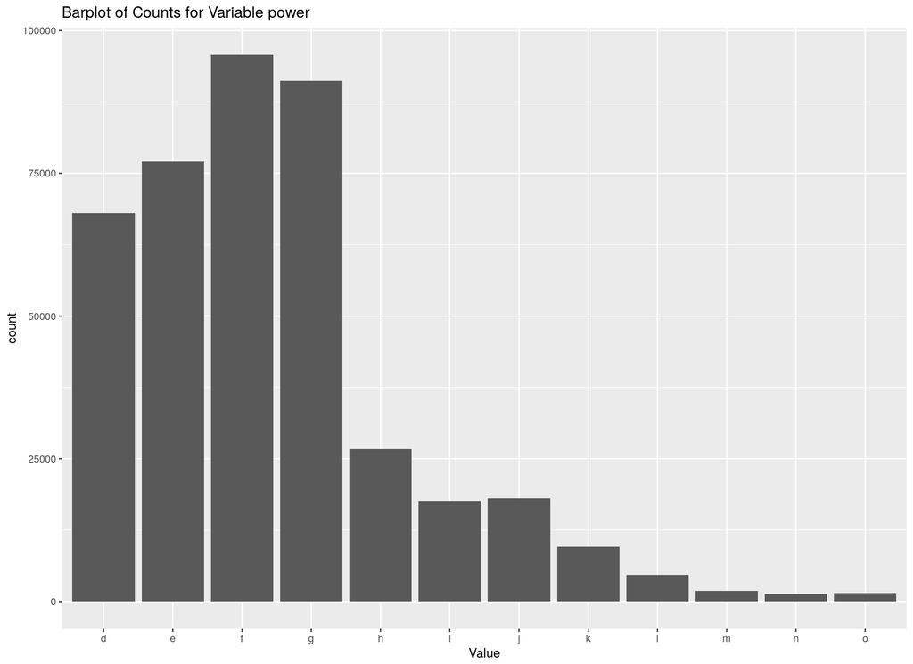

```r
ggplot(policyclaim_dt) +
    geom_bar(aes(x = power)) +
    xlab('Value') +
    ggtitle("Barplot of Counts for Variable power")
```

There is quite a long tail for the higher letters, so we redo this plot showing the total count of the policies as we account for additional power levels. This should give us a sense for the point at which we agglomerate the levels into a single value.

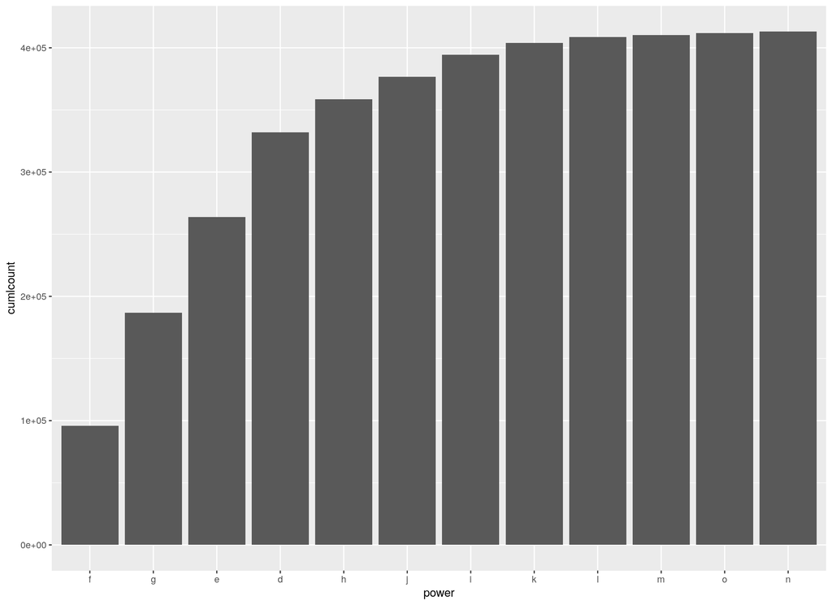

```r
plot_dt <- policyclaim_dt %>%
    group_by(power) %>%
    summarise(count = length(policy_id)) %>%
    arrange(-count) %>%
    summarise(power, cumlcount = cumsum(count))

plot_dt$power <- factor(plot_dt$power, levels = plot_dt$power)

ggplot(plot_dt) +
    geom_bar(aes(x = power, y = cumlcount), stat = 'identity')
```

Looking this plot, we see that the levels from $i$ on in the plot can be aggregated. We combine $(i,k,l,m,o,n)$ into a single level `other`.

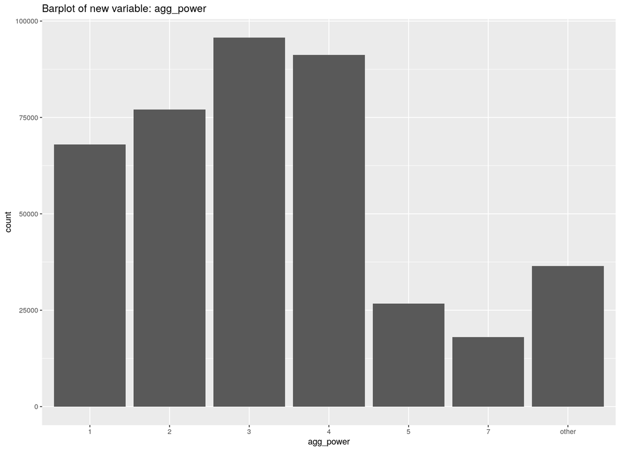

```r
power_other <- c('i','k','l','m','o','n')

policyclaim_dt <- policyclaim_dt %>%
    mutate(agg_power = ifelse(power %in% power_other, 'other', power))

ggplot(policyclaim_dt) +
    geom_bar(aes(x = agg_power)) +
    ggtitle("Barplot of new variable: agg_power")
```

We may have been slightly too aggressive with this, so just in case, we create a new variable `agg_power_2` where we keep value $i$ separate and aggregate the others.

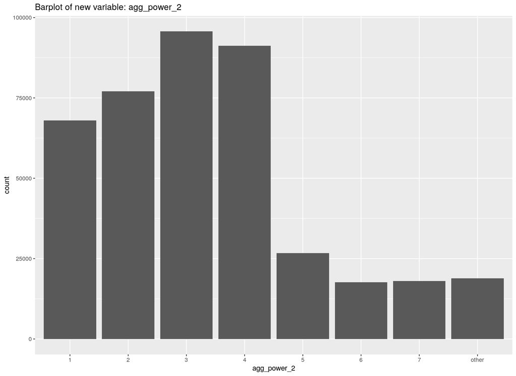

```r
power_other <- c('k','l','m','o','n')

policyclaim_dt <- policyclaim_dt %>%
    mutate(agg_power_2 = ifelse(power %in% power_other, 'other', power))

ggplot(policyclaim_dt) +
    geom_bar(aes(x = agg_power_2)) +
    ggtitle("Barplot of new variable: agg_power_2")
```

`agg_power_2` would appear to be a better aggregation of levels in terms of balanced counts - though it should be said that this may not be in anyway good or desirable.

### 4.2.2 region

The `region` variable is imbalanced, so we give it similar treatment.

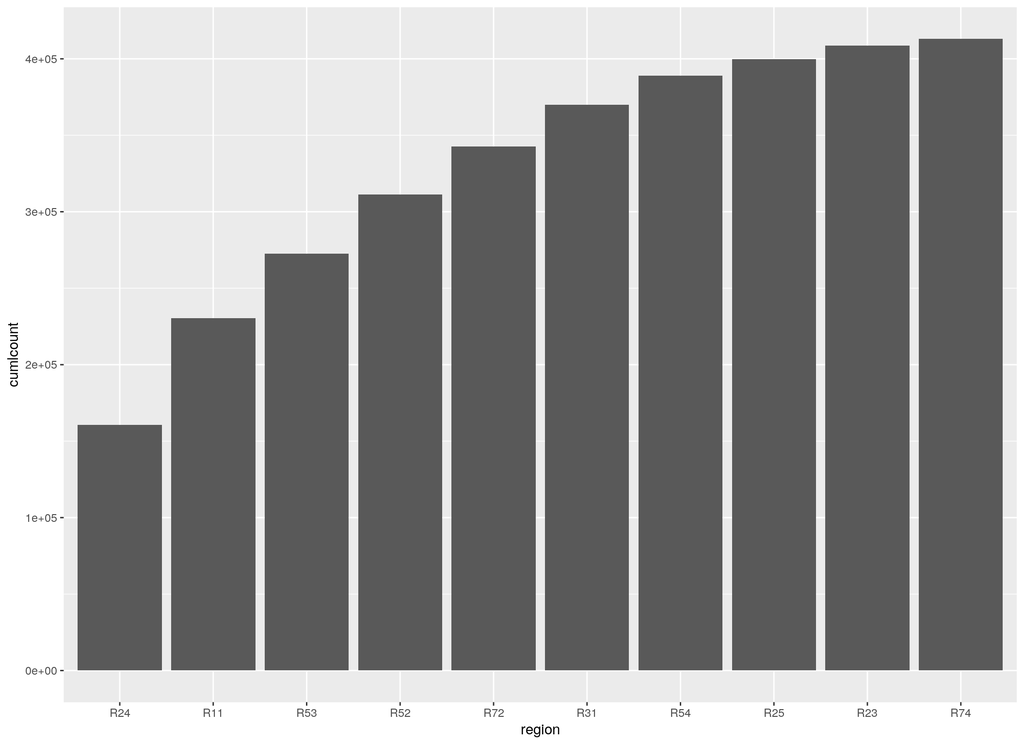

```r
plot_dt <- policyclaim_dt %>%
    group_by(region) %>%
    summarise(count = length(policy_id)) %>%
    arrange(-count) %>%
    summarise(region, cumlcount = cumsum(count))

plot_dt$region <- factor(plot_dt$region, levels = plot_dt$region)

ggplot(plot_dt) +
    geom_bar(aes(x = region, y = cumlcount), stat = 'identity')
```

We will try to aggregate up the last three values: $R25$, $R23$ and $R74$:

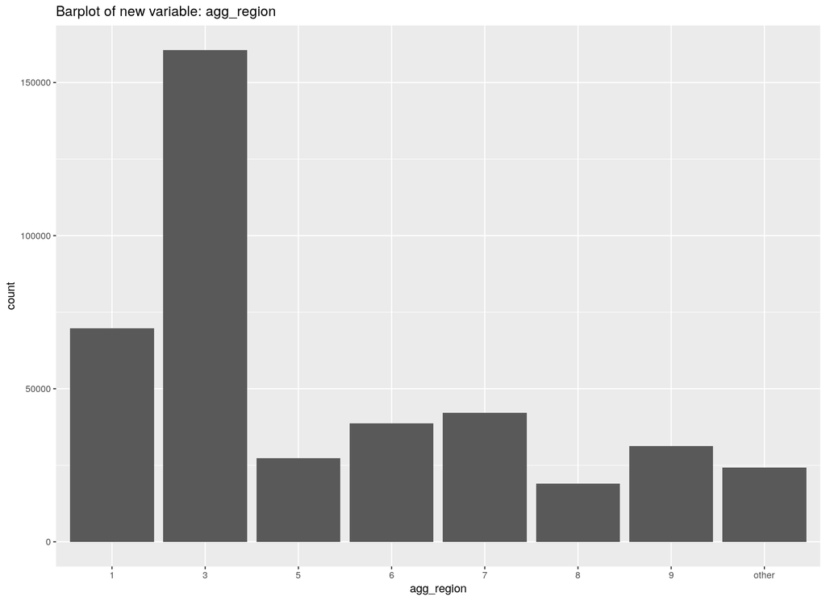

```r
region_other <- c('R25','R23','R74')

policyclaim_dt <- policyclaim_dt %>%
    mutate(agg_region = ifelse(region %in% region_other, 'other', region))

ggplot(policyclaim_dt) +
    geom_bar(aes(x = agg_region)) +
    ggtitle("Barplot of new variable: agg_region")
```

While not balanced, `agg_region` has much less of a tail. It will be interesting to see if this aggregation has any effect on model performance.

# 5 Write to Disk

We have done some chopping and munging with this data, and we wish to preserve some of this work across the documents so we save them to disk in both CSV and feather format.

```r
### We first drop variable num_claim as it repeats claim_count
policyclaim_dt <- policyclaim_dt %>% select(-num_claim)


write.csv(policy1_dt,         file = 'data/policy_data.csv',      row.names = FALSE)
write.csv(claims1_dt,         file = 'data/claim_data.csv',       row.names = FALSE)
write.csv(policyclaim_dt,     file = 'data/policyclaim_data.csv', row.names = FALSE)

write_feather(policy1_dt,     path = 'data/policy_data.feather')
write_feather(claims1_dt,     path = 'data/claim_data.feather')
write_feather(policyclaim_dt, path = 'data/policyclaim_data.feather')
```